# Missing Data

## Dealing with Missing Data

## Missing data types

One of the most important aspects of data cleaning is missing values.

Types of “missing” data:

- `NA` - general missing data
- `NaN` - stands for “**N**ot **a** **N**umber”, happens when you do 0/0.
- `Inf` and `-Inf` - Infinity, happens when you take a positive number (or negative number) by 0.

## Missing Data with Logicals

Logical operations return `NA` for `NA` values. Think about it, the data could be `> 2` or not we don’t know, so `R` says there is no `TRUE` or `FALSE`, so that is missing:

```r
x <- c(0, NA, 2, 3, 4)
x > 2
```

```
[1] FALSE    NA FALSE  TRUE  TRUE
```

## Missing Data Issues

Mathematical operations with `NA` result in `NA`s.

```r
y <- c(1,2,3,NA)
sum(y)
```

```
[1] NA
```

```r
mean(y)
```

```
[1] NA
```

## Missing Data Issues

Logicals: `TRUE` is evaluated as 1 and `FALSE` is evaluated as 0.

```r
x <- c(TRUE, TRUE, TRUE, TRUE, FALSE, NA)
sum(x)
```

```
[1] NA
```

```r
sum(x, na.rm = TRUE)
```

```
[1] 4
```

## Finding Missing data

- `is.na` - looks for `NAN` and `NA`
- `is.nan`- looks for `NAN`

```r
test <- c(0,NA, -1, NaN)
is.na(test)
```

```
[1] FALSE  TRUE FALSE  TRUE
```

```r
is.nan(test)
```

```
[1] FALSE FALSE FALSE  TRUE
```

## Useful checking functions

Do we have any `NA`s? (`any` can help)

```r
A <- c(1, 2, 3, NA)
B <- c(1, 2, 3, 4)
```

```r
any(is.na(A)) # are there any NAs - YES/TRUE
```

```
[1] TRUE
```

```r
any(is.na(B)) # are there any NAs- NO/FALSE
```

```
[1] FALSE
```

## Finding `NA` values with `count()`

Check the values for your variables, are they what you expect?

`count()` is a great option because it gives you:

1. The unique values
2. The amount of these values

Check if rare values make sense.

## Finding `NA` values with `count()`

```r
library(readr)
library(janitor)
ufo <- read_csv(
  "https://sisbid.github.io/Data-Wrangling/data/ufo/ufo_data_complete.csv")
```

```
Warning: One or more parsing issues, call `problems()` on your data frame for details, e.g.:
  dat <- vroom(...)
  problems(dat)
```

```r
ufo <- clean_names(ufo)

count(ufo, country)
```

```
# A tibble: 6 × 2
  country     n
  <chr>   <int>
1 au        593
2 ca       3266
3 de        112
4 gb       2050
5 us      70293
6 <NA>    12561
```

## `naniar`

Sometimes you need to look at lots of data… the [`naniar` package](https://cran.r-project.org/web/packages/naniar/vignettes/getting-started-w-naniar.html) is a good option.

```r
#install.packages("naniar")
library(naniar)
```

## naniar: `pct_complete()`

This can tell you if there are missing values in the dataset.

```r
pct_complete(ufo)
```

```
[1] 97.27646
```

Or for a particular variable:

```r
ufo %>% select(shape) %>%
pct_complete()
```

```
[1] 96.4917
```

## naniar:`miss_var_summary()`

To get the percent missing (and counts) for each variable as a table, use this function.

```r
miss_var_summary(ufo)
```

```
# A tibble: 11 × 3
   variable           n_miss pct_miss
   <chr>               <int>    <num>
 1 country             12561 14.1
 2 state                7519  8.46
 3 shape                3118  3.51
 4 duration_hours_min   3101  3.49
 5 city                  196  0.221
 6 comments              126  0.142
 7 duration_seconds        5  0.00563
 8 datetime                0  0
 9 date_posted             0  0
10 latitude                0  0
11 longitude               0  0
```

## `naniar` plots of number missing

The `gg_miss_var()` function creates a nice plot about the number of missing values for each variable, (need a data frame).

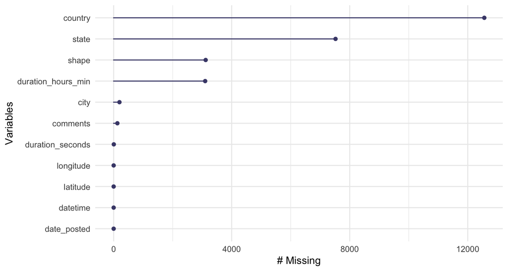

```r
gg_miss_var(ufo)
```

## `naniar` plots of percent missing

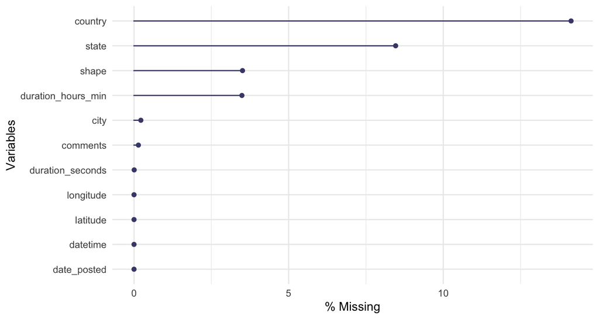

```r
gg_miss_var(ufo, show_pct = TRUE)
```

## filter() and missing data

Be **careful** with missing data using subsetting!

**`filter()` removes missing values by default.** Because R can’t tell for sure if an `NA` value meets the condition. To keep them need to add `is.na()` conditional.

Think about if this is OK or not - it depends on your data!

## filter() and missing data

What if NA values represent values that are so low it is undetectable?

Filter will drop them from the data.

```r
count(ufo, country)
```

```
# A tibble: 6 × 2
  country     n
  <chr>   <int>
1 au        593
2 ca       3266
3 de        112
4 gb       2050
5 us      70293
6 <NA>    12561
```

```r
ufo %>% filter(country == "de") %>% dim()
```

```
[1] 112  11
```

## filter() and missing data

`is.na()` can help us keep them.

```r
ufo %>% filter(country == "de" | is.na(country)) %>% dim()
```

```
[1] 12673    11
```

## To remove **rows** with `NA` values for a **variable** use `drop_na()`

A function from the `tidyr` package. (Need a data frame to start!)

Disclaimer: Don’t do this unless you have thought about if dropping `NA` values makes sense based on knowing what these values mean in your data.

```r
ufo
```

```
# A tibble: 88,875 × 11
   datetime        city  state country shape duration_seconds duration_hours_min
   <chr>           <chr> <chr> <chr>   <chr>            <dbl> <chr>
 1 10/10/1949 20:… san … tx    us      cyli…             2700 45 minutes
 2 10/10/1949 21:… lack… tx    <NA>    light             7200 1-2 hrs
 3 10/10/1955 17:… ches… <NA>  gb      circ…               20 20 seconds
 4 10/10/1956 21:… edna  tx    us      circ…               20 1/2 hour
 5 10/10/1960 20:… kane… hi    us      light              900 15 minutes
 6 10/10/1961 19:… bris… tn    us      sphe…              300 5 minutes
 7 10/10/1965 21:… pena… <NA>  gb      circ…              180 about 3 mins
 8 10/10/1965 23:… norw… ct    us      disk              1200 20 minutes
 9 10/10/1966 20:… pell… al    us      disk               180 3  minutes
10 10/10/1966 21:… live… fl    us      disk               120 several minutes
# ℹ 88,865 more rows
# ℹ 4 more variables: comments <chr>, date_posted <chr>, latitude <chr>,
#   longitude <chr>
```

## To remove **rows** with `NA` values for a **variable** use `drop_na()`

```r
ufo %>% drop_na(state)
```

```
# A tibble: 81,356 × 11
   datetime        city  state country shape duration_seconds duration_hours_min
   <chr>           <chr> <chr> <chr>   <chr>            <dbl> <chr>
 1 10/10/1949 20:… san … tx    us      cyli…             2700 45 minutes
 2 10/10/1949 21:… lack… tx    <NA>    light             7200 1-2 hrs
 3 10/10/1956 21:… edna  tx    us      circ…               20 1/2 hour
 4 10/10/1960 20:… kane… hi    us      light              900 15 minutes
 5 10/10/1961 19:… bris… tn    us      sphe…              300 5 minutes
 6 10/10/1965 23:… norw… ct    us      disk              1200 20 minutes
 7 10/10/1966 20:… pell… al    us      disk               180 3  minutes
 8 10/10/1966 21:… live… fl    us      disk               120 several minutes
 9 10/10/1968 13:… hawt… ca    us      circ…              300 5 min.
10 10/10/1968 19:… brev… nc    us      fire…              180 3 minutes
# ℹ 81,346 more rows
# ℹ 4 more variables: comments <chr>, date_posted <chr>, latitude <chr>,
#   longitude <chr>
```

## Drop all NAs with `drop_na()`

Drops rows with **any** missing data in **any** column.

```r
ufo %>% drop_na() %>% dim()
```

```
[1] 69528    11
```

```r
ufo %>% drop_na()
```

```
# A tibble: 69,528 × 11
   datetime        city  state country shape duration_seconds duration_hours_min
   <chr>           <chr> <chr> <chr>   <chr>            <dbl> <chr>
 1 10/10/1949 20:… san … tx    us      cyli…             2700 45 minutes
 2 10/10/1956 21:… edna  tx    us      circ…               20 1/2 hour
 3 10/10/1960 20:… kane… hi    us      light              900 15 minutes
 4 10/10/1961 19:… bris… tn    us      sphe…              300 5 minutes
 5 10/10/1965 23:… norw… ct    us      disk              1200 20 minutes
 6 10/10/1966 20:… pell… al    us      disk               180 3  minutes
 7 10/10/1966 21:… live… fl    us      disk               120 several minutes
 8 10/10/1968 13:… hawt… ca    us      circ…              300 5 min.
 9 10/10/1968 19:… brev… nc    us      fire…              180 3 minutes
10 10/10/1970 16:… bell… ny    us      disk              1800 30 min.
# ℹ 69,518 more rows
# ℹ 4 more variables: comments <chr>, date_posted <chr>, latitude <chr>,
#   longitude <chr>
```

## Find columns with any missing values

Use the `miss_var_which()` function from `naniar`

```r
miss_var_which(ufo) # which columns have missing values
```

```
[1] "city"               "state"              "country"
[4] "shape"              "duration_seconds"   "duration_hours_min"
[7] "comments"
```

## Drop **columns** with any missing values

`miss_var_which` and function from `naniar` (need a data frame)

```r
ufo %>% select(!miss_var_which(ufo))
```

```
# A tibble: 88,875 × 4
   datetime         date_posted latitude   longitude
   <chr>            <chr>       <chr>      <chr>
 1 10/10/1949 20:30 4/27/2004   29.8830556 -97.9411111
 2 10/10/1949 21:00 12/16/2005  29.38421   -98.581082
 3 10/10/1955 17:00 1/21/2008   53.2       -2.916667
 4 10/10/1956 21:00 1/17/2004   28.9783333 -96.6458333
 5 10/10/1960 20:00 1/22/2004   21.4180556 -157.8036111
 6 10/10/1961 19:00 4/27/2007   36.5950000 -82.1888889
 7 10/10/1965 21:00 2/14/2006   51.434722  -3.18
 8 10/10/1965 23:45 10/2/1999   41.1175000 -73.4083333
 9 10/10/1966 20:00 3/19/2009   33.5861111 -86.2861111
10 10/10/1966 21:00 5/11/2005   30.2947222 -82.9841667
# ℹ 88,865 more rows
```

## Change a value to be `NA`

Let’s say we think that all 0 values should be `NA`.

The `na_if()` function of `dplyr` can be helpful for changing all 0 values to `NA`. More on `mutate()` soon! (Here we save the change)

```r
count(ufo, duration_seconds) %>% tail()
```

```
# A tibble: 6 × 2
  duration_seconds     n
             <dbl> <int>
1         25248000     1
2         52623200     3
3         66276000     1
4         82800000     1
5         97836000     1
6               NA     5
```

## Change a value to be `NA`

```r
ufo <- ufo %>%
  mutate(duration_seconds = na_if(duration_seconds, 0))

count(ufo, duration_seconds) %>% tail()
```

```
# A tibble: 6 × 2
  duration_seconds     n
             <dbl> <int>
1         25248000     1
2         52623200     3
3         66276000     1
4         82800000     1
5         97836000     1
6               NA  7228
```

## Change `NA` to be a value

The `replace_na()` function (part of the `tidyr` package), can do the opposite of `na_if()`. (Here we just print the change)

```r
count(ufo, shape) %>% tail()
```

```
# A tibble: 6 × 2
  shape        n
  <chr>    <int>
1 round        2
2 sphere    5755
3 teardrop   817
4 triangle  8489
5 unknown   6319
6 <NA>      3118
```

## Change `NA` to be a value

The `replace_na()` function (part of the `tidyr` package), can do the opposite of `na_if()`. (Here we just print the change)

```r
ufo %>%
  mutate(shape = replace_na(shape, "unknown")) %>%
  count(shape) %>% tail()
```

```
# A tibble: 6 × 2
  shape         n
  <chr>     <int>
1 rectangle  1418
2 round         2
3 sphere     5755
4 teardrop    817
5 triangle   8489
6 unknown    9437
```

## Think about `NA`

THINK ABOUT YOUR DATA FIRST!

⚠️ Sometimes removing `NA` values leads to distorted math - be careful!

⚠️ Think about what your `NA` means for your data (are you sure ?).

- Is an `NA` for values so low they could not be reported?
- Or is it if it was too low and also if there was a different issue (like no one reported)?

## Think about `NA`

If it is something more like a zero then you might want it included in your data like a zero instead of an `NA`.

Example: - survey reports `NA` if student has never tried cigarettes - survey reports 0 if student has tried cigarettes but did not smoke that week

⚠️ You might want to keep the `NA` values so that you know the original sample size.

## Word of caution

⚠️ Calculating percentages will give you a different result depending on your choice to include NA values.!

This is because the denominator changes.

## Word of caution - Percentages with `NA`

```r
count(ufo, country) %>% mutate(percent = (n/(sum(n)) *100)) %>%
  arrange(desc(percent))
```

```
# A tibble: 6 × 3
  country     n percent
  <chr>   <int>   <dbl>
1 us      70293  79.1
2 <NA>    12561  14.1
3 ca       3266   3.67
4 gb       2050   2.31
5 au        593   0.667
6 de        112   0.126
```

## Word of caution - Percentages with `NA`

```r
ufo %>% drop_na(country) %>%
count(country) %>% mutate(percent = (n/(sum(n)) *100)) %>%
  arrange(desc(percent))
```

```
# A tibble: 5 × 3
  country     n percent
  <chr>   <int>   <dbl>
1 us      70293  92.1
2 ca       3266   4.28
3 gb       2050   2.69
4 au        593   0.777
5 de        112   0.147
```

Should you be dividing by the total count with `NA` values included?  
It depends on your data and what `NA` might mean.  
Pay attention to your data and your `NA` values!

## Summary

- `is.na()`,`any(is.na())`, `count()`, and functions from `naniar` like `gg_miss_var()` can help determine if we have `NA` values
- `filter()` automatically removes `NA` values - can’t confirm or deny if condition is met (need `| is.na()` to keep them)
- `drop_na()` can help you remove `NA` values from a variable or an entire data frame
- `NA` values can change your calculation results
- think about what `NA` values represent - don’t drop them if you shouldn’t

[Link to Lab](https://sisbid.github.io/Data-Wrangling/06_Missing_Data/lab/missing-data-lab.Rmd)